# Donor Profile: Australia for UNHCR

## Transaction Volatility

Australia’s current average transaction value of $131K through 141 transactions annually starkly contrasts with top donors’ $2.9M across 587 transactions, exposing a significant funding scale gap. This volatility and comparatively low funding volume limit impact and risk continuity in UNHCR programs reliant on Australian contributions. Strategic investment to increase transaction size and frequency would leverage Australia’s donor potential as a key growth priority, amplifying emergency response and resilience outcomes. Immediate executive action to strengthen partnership frameworks, optimize engagement timing, and advocate targeted funding mechanisms could unlock substantial impact multipliers. Mobilizing major donors with clear evidence of underutilized capacity and measurable return on investment addresses donor priorities for accountability and innovation. UNHCR stands ready to transform this funding gap into a strategic growth opportunity that strengthens program sustainability and global partnership resilience.

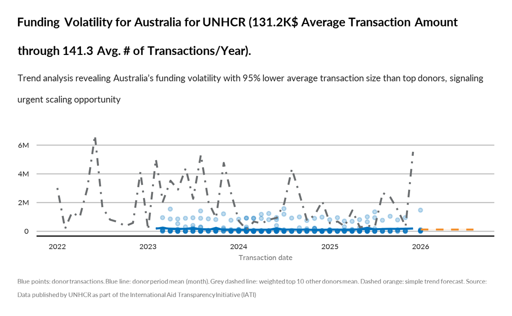

TRUE